# 衡量機器學習模型的表現

Yao-Jen Kuo

June, 2016

# 好的機器學習模型

一個好的機器學習模型大致上具有這幾個特性:

- 準確度高
- 計算時間短(2007 Netflix Prize)
- 可以適用到未知資料

# 基本機器學習模型的對應衡量指標

| 機器學習模型 | 衡量表現指標 |
| --- | --- |
| 分類(Classification) | 混淆矩陣Confusion Matrix |
| 迴歸(Regression) | 均方根誤差RMSE(Root Mean Squared Error) |
|  | R平方R-Squared |
| 分群(Clustering) | WSS/TSS比例 |
|  | 唐恩指數Dunn’s Index |

# 混淆矩陣Confusion Matrix

- 以二元分類器為例:

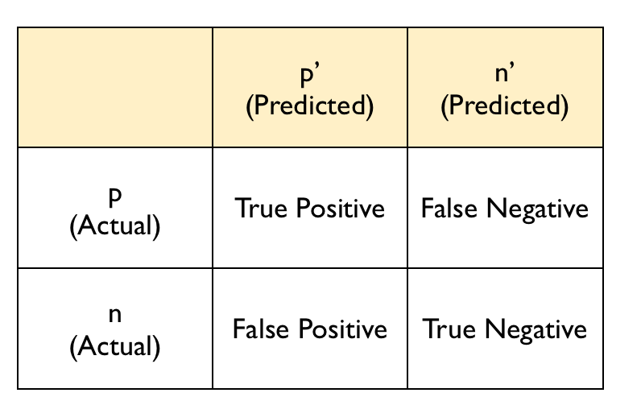

Source: Google Search

- 有很多的衡量指標由混淆矩陣衍生而來:

$$Accuracy = \frac{TP + TN}{TP + FP + FN + TN}$$

- 光使用 Accuracy 來判定會有什麼問題?
- 假設有一個預測罕見疾病的分類器, 這個罕見疾病的比例大約是1%
- 我們的分類器很粗糙, 它一律猜測所有觀測值(病人)都沒有該疾病(陰性Negative):

|  | Positive | Negative |
| --- | --- | --- |
| Positive | 0 | 10 |
| Negative | 0 | 990 |

$$Accuracy = \frac{990 + 0}{990 + 10 + 0 + 0} = 0.99$$

- 因此關於混淆矩陣我們還有其他的指標:

$$TPR = \frac{TP}{TP + FN}$$

$$FPR = \frac{FP}{FP + TN}$$

- 還有其他的…但我們先緩一緩吧…

# 混淆矩陣Confusion Matrix - Hands On

- [資料集](https://www.kaggle.com/c/titanic/data)

```r
# 載入需要的套件
library(magrittr)
library(rpart)

# 讀取資料
titanic <- read.csv("/Users/tkuo/ntu_train/NTUTrainRL3/data/train.csv", header = TRUE)
titanic <- titanic[, c(2, 3, 5, 6)] %>% na.omit
titanic$Survived <- factor(titanic$Survived, levels = c(1, 0))
str(titanic)
```

```
## 'data.frame':    714 obs. of  4 variables:
##  $ Survived: Factor w/ 2 levels "1","0": 2 1 1 1 2 2 2 1 1 1 ...
##  $ Pclass  : int  3 1 3 1 3 1 3 3 2 3 ...
##  $ Sex     : Factor w/ 2 levels "female","male": 2 1 1 1 2 2 2 1 1 1 ...
##  $ Age     : num  22 38 26 35 35 54 2 27 14 4 ...
##  - attr(*, "na.action")=Class 'omit'  Named int [1:177] 6 18 20 27 29 30 32 33 37 43 ...
##   .. ..- attr(*, "names")= chr [1:177] "6" "18" "20" "27" ...
```

```r
# 建立一個決策樹模型
set.seed(123)
treeModel <- rpart(Survived ~ ., data = titanic, method = "class")
titanicToBePredicted <- titanic[, -1]
prediction <- predict(treeModel, newdata = titanicToBePredicted, type = "class")

# 將混淆矩陣印出來
confusionMatrix <- table(titanic$Survived, prediction, dnn = c("Actual", "Predicted"))
confusionMatrix
```

```
##       Predicted
## Actual   1   0
##      1 212  78
##      0  53 371
```

```r
# 獲得TP, TN, FP, FN
TP <- confusionMatrix[1, 1]
TN <- confusionMatrix[2, 2]
FP <- confusionMatrix[2, 1]
FN <- confusionMatrix[1, 2]

# 計算accuracy, TPR, FPR
accuracy <- (TP + TN)/(TP + TN + FP + FN)
accuracy <- sum(diag(confusionMatrix))/sum(confusionMatrix)# 試試這樣算
TPR <- TP/(TP + FN)
FPR <- FP/(FP + TN)

# accuracy, TPR, FPR
accuracy
```

```
## [1] 0.8165266
```

```r
TPR
```

```
## [1] 0.7310345
```

```r
FPR
```

```
## [1] 0.125
```

# 混淆矩陣Confusion Matrix - Do It Yourself

- 這次換你囉, 加入`Fare`, `Cabin`, 與`Embarked`這三個變數試試看!
- 印出混淆矩陣
- 計算 accuracy, TPR與FPR

```r
# 讀取資料
titanic <- read.csv("/Users/tkuo/ntu_train/NTUTrainRL3/data/train.csv", header = TRUE)
titanic <- titanic[, c(2, 3, 5, 6, 10:12)] %>% na.omit
titanic$Survived <- factor(titanic$Survived, levels = c(1, 0))
str(titanic)
```

```
## 'data.frame':    714 obs. of  7 variables:
##  $ Survived: Factor w/ 2 levels "1","0": 2 1 1 1 2 2 2 1 1 1 ...
##  $ Pclass  : int  3 1 3 1 3 1 3 3 2 3 ...
##  $ Sex     : Factor w/ 2 levels "female","male": 2 1 1 1 2 2 2 1 1 1 ...
##  $ Age     : num  22 38 26 35 35 54 2 27 14 4 ...
##  $ Fare    : num  7.25 71.28 7.92 53.1 8.05 ...
##  $ Cabin   : Factor w/ 148 levels "","A10","A14",..: 1 83 1 57 1 131 1 1 1 147 ...
##  $ Embarked: Factor w/ 4 levels "","C","Q","S": 4 2 4 4 4 4 4 4 2 4 ...
##  - attr(*, "na.action")=Class 'omit'  Named int [1:177] 6 18 20 27 29 30 32 33 37 43 ...
##   .. ..- attr(*, "names")= chr [1:177] "6" "18" "20" "27" ...
```

```r
# 建立一個決策樹模型
set.seed(123)
treeModel <- rpart(Survived ~ ., data = titanic, method = "class")
titanicToBePredicted <- titanic[, -1]
prediction <- predict(treeModel, newdata = titanicToBePredicted, type = "class")

# 將混淆矩陣印出來
confusionMatrix <- table(titanic$Survived, prediction, dnn = c("Actual", "Predicted"))
confusionMatrix
```

```
##       Predicted
## Actual   1   0
##      1 215  75
##      0  19 405
```

```r
# 獲得TP, TN, FP, FN
TP <- confusionMatrix[1, 1]
TN <- confusionMatrix[2, 2]
FP <- confusionMatrix[2, 1]
FN <- confusionMatrix[1, 2]

# 計算accuracy, TPR, FPR
accuracy <- (TP + TN)/(TP + TN + FP + FN)
accuracy <- sum(diag(confusionMatrix))/sum(confusionMatrix)# 試試這樣算
TPR <- TP/(TP + FN)
FPR <- FP/(FP + TN)

# accuracy, TPR, FPR
accuracy
```

```
## [1] 0.8683473
```

```r
TPR
```

```
## [1] 0.7413793
```

```r
FPR
```

```
## [1] 0.04481132
```

# 均方根誤差RMSE

- 資料點與預測迴歸線的平均距離

$$RMSE = \sqrt{\frac{1}{N}\sum_{i=1}^N (y_i - \hat{y}_i)^2}$$

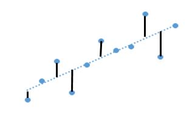

Source: Google Search

# 均方根誤差RMSE - Hands on

```r
# 氣溫與冰紅茶銷量
temperature <- c(29, 28, 34, 31, 25, 29, 32, 31, 24, 33, 25, 31, 26, 30)
icedTeaSales <- c(77, 62, 93, 84, 59, 64, 80, 75, 58, 91, 51, 73, 65, 84)
icedTeaData <- data.frame(temperature, icedTeaSales)

# 建立一個線性迴歸模型
lmFit <- lm(formula = icedTeaSales ~ temperature, data = icedTeaData)
icedTeaDataToBePredicted <- data.frame(icedTeaData[, -2])
prediction <- predict(lmFit, newdata = icedTeaDataToBePredicted)
RMSE <- sqrt(sum( (icedTeaData$icedTeaSales - prediction) ^ 2) / nrow(icedTeaData))
RMSE
```

```
## [1] 5.285344
```

# 均方根誤差RMSE - Do It Yourself(1)

- 來這裡下載資料集[airUCI](https://archive.ics.uci.edu/ml/datasets/Airfoil+Self-Noise#)
- 使用常用的函數暸解 `airUCI` 的結構
- 只使用`freq`, `angle`, 以及`chLength`這三個變數來預測`dec`
- 使用 `+` 在 `formula` 連接多個變數
- 計算RMSE1

```r
# 直接從UCI讀入資料集
airUCI <- read.table("https://archive.ics.uci.edu/ml/machine-learning-databases/00291/airfoil_self_noise.dat", header = FALSE, col.names = c("freq", "angle", "chLength", "velocity", "thickness", "dec"))
# 建立一個線性模型lmFit_1, 用練習題規定的三個變數預測dec
lmFit_1 <- lm(formula = dec ~ freq + angle + chLength, data = airUCI)
# 將原始資料的三個變數篩選出
airUCIToBePredicted <- data.frame(airUCI[, c(1:3)])
# 用建好的模型預測dec
prediction <- predict(lmFit_1, newdata = airUCIToBePredicted)
# 再利用公式計算預測趨勢線與實際值的的RMSE
RMSE1 <- sqrt(sum( (airUCI$dec - prediction) ^ 2) / nrow(airUCI))
RMSE1
```

```
## [1] 5.215778
```

# 均方根誤差RMSE - Do It Yourself(2)

- 再加入`velocity`以及`thickness`這兩個變數, 共5個變數來預測`dec`
- 計算RMSE2
- 比較RMSE1與RMSE2

```r
# 建立一個線性模型lmFit_2, 用規定的五個變數預測dec
lmFit_2 <- lm(formula = dec ~ freq + angle + chLength + velocity + thickness, data = airUCI)
# 將原始資料的五個變數篩選出
airUCIToBePredicted <- data.frame(airUCI[, c(1:5)])
# 用建好的模型預測dec
prediction <- predict(lmFit_2, newdata = airUCIToBePredicted)
# 再利用公式計算預測趨勢線與實際值的的RMSE
RMSE2 <- sqrt(sum( (airUCI$dec - prediction) ^ 2) / nrow(airUCI))

# 比較 RMSE1 與 RMSE2
RMSE2 - RMSE1
```

```
## [1] -0.4165337
```

# R平方R-Squared

- y變數的變異有多少比例可以被x變數預測

$$SS_{res} = \sum_{i=1}^N(y_i - \hat{y}_i) ^ 2$$
$$SS_{tot} = \sum_{i=1}^N(y_i - \bar{y}) ^ 2$$
$$R^2 = 1 - \frac{SS_{res}}{SS_{tot}}$$

# R平方R-Squared - Hands on

```r
icedTeaSalesEst <- predict(lmFit, newdata = data.frame(icedTeaData[, 1]))

# 計算R-squared
res <- icedTeaData$icedTeaSales - icedTeaSalesEst
ss_res <- sum (res ^ 2)
ss_tot <- sum( (icedTeaData$icedTeaSales - mean(icedTeaData$icedTeaSales))^2 )
r_sq <- 1 - ss_res / ss_tot
r_sq
```

```
## [1] 0.8225093
```

```r
# 跟 summary() 的結果比較
summary(lmFit)$r.squared
```

```
## [1] 0.8225093
```

# R平方R-Squared - Do It Yourself

- 延續使用資料集[airUCI](https://archive.ics.uci.edu/ml/datasets/Airfoil+Self-Noise#)
- 只使用`freq`, `angle`, 以及`chLength`這三個變數來預測`dec`
- 自行計算R平方
- 與 `summary()` 的結果比較

```r
lmFit <- lm(formula = dec ~ freq + angle + chLength, data = airUCI)

decEst <- predict(lmFit, newdata = data.frame(airUCI[, 1:3]))

# 計算R-squared
res <- airUCI$dec - decEst
ss_res <- sum (res ^ 2)
ss_tot <- sum( (airUCI$dec - mean(airUCI$dec))^2 )
r_sq <- 1 - ss_res / ss_tot
r_sq
```

```
## [1] 0.4279971
```

```r
# 跟 summary() 的結果比較
summary(lmFit)$r.squared
```

```
## [1] 0.4279971
```

# WSS / TSS 比例

- 同一個群集中的**相似度**要高
- 不同群集之間的**相似度**要低
- 我們先使用**WSS / TSS**來判別分群模型的表現
- 組內距離平方和WSS(Within Cluster Sum of Squares)

$$Min.\,WSS = \sum_{i=1}^{N_C}\sum_{x \in C_i}d(x,\,\bar{x}_{C_i})^2$$

- 組間距離平方和BSS(Between Cluster Sum of Squares)

$$Max.\,BSS = \sum_{i=1}^{N_C}\lvert C_i \rvert \cdot d(\bar{x}_{C_i},\,\bar{x})^2$$

- 總離均差平方和TSS(Total Cluster Sum of Squares)

$$TSS = WSS + BSS$$

# WSS / TSS 比例 - Hands on

```r
# 看看鳶尾花資料集的結構
str(iris)
```

```
## 'data.frame':    150 obs. of  5 variables:
##  $ Sepal.Length: num  5.1 4.9 4.7 4.6 5 5.4 4.6 5 4.4 4.9 ...
##  $ Sepal.Width : num  3.5 3 3.2 3.1 3.6 3.9 3.4 3.4 2.9 3.1 ...
##  $ Petal.Length: num  1.4 1.4 1.3 1.5 1.4 1.7 1.4 1.5 1.4 1.5 ...
##  $ Petal.Width : num  0.2 0.2 0.2 0.2 0.2 0.4 0.3 0.2 0.2 0.1 ...
##  $ Species     : Factor w/ 3 levels "setosa","versicolor",..: 1 1 1 1 1 1 1 1 1 1 ...
```

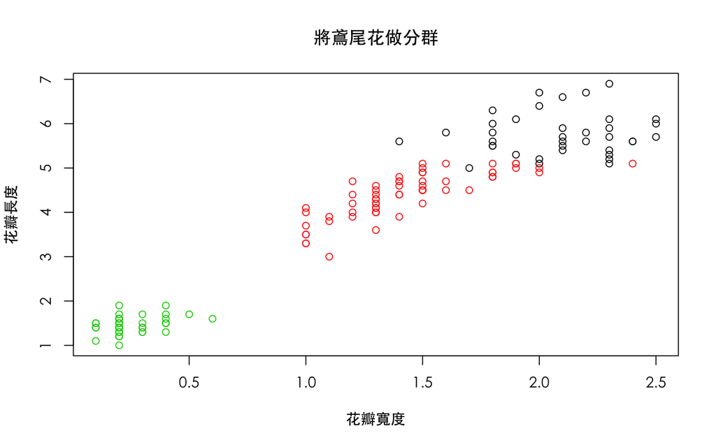

```r
# 建立一個分群模型
irisCluster <- iris[-5]
kmeansIris<-kmeans(irisCluster, centers = 3)

# 作圖
plot(formula = Petal.Length ~ Petal.Width, data = irisCluster, col = kmeansIris$cluster, main = "將鳶尾花做分群", xlab = "花瓣寬度", ylab = "花瓣長度", family = "STHeiti")
```

```r
# 計算WSS/TSS的比例
WSS <- kmeansIris$tot.withinss
BSS <- kmeansIris$betweenss
ratio <- WSS/(WSS + BSS)
ratio
```

```
## [1] 0.1157247
```

# WSS / TSS 比例 - Do It Yourself

- 來這裡下載資料集[seedsUCI](https://archive.ics.uci.edu/ml/datasets/seeds)
- 使用常用函數了解資料框
- 仿照前例, 計算WSS/TSS

```r
seedsUCI <- read.csv("/Users/tkuo/ntu_train/NTUTrainRL3/data/seedsUCI.csv", header = FALSE, col.names = c("area", "perimeter", "compactness", "length", "width", "asymmetry", "grooveLength", "type"))
str(seedsUCI)
```

```
## 'data.frame':    210 obs. of  8 variables:
##  $ area        : num  15.3 14.9 14.3 13.8 16.1 ...
##  $ perimeter   : num  14.8 14.6 14.1 13.9 15 ...
##  $ compactness : num  0.871 0.881 0.905 0.895 0.903 ...
##  $ length      : num  5.76 5.55 5.29 5.32 5.66 ...
##  $ width       : num  3.31 3.33 3.34 3.38 3.56 ...
##  $ asymmetry   : num  2.22 1.02 2.7 2.26 1.35 ...
##  $ grooveLength: num  5.22 4.96 4.83 4.8 5.17 ...
##  $ type        : int  1 1 1 1 1 1 1 1 1 1 ...
```

```r
seedsUCIToBeClustered <- seedsUCI[, -8]
kmeansSeeds<-kmeans(seedsUCIToBeClustered, centers = 3)

# 計算WSS/TSS的比例
WSS <- kmeansSeeds$tot.withinss
BSS <- kmeansSeeds$betweenss
ratio <- WSS/(WSS + BSS)
ratio
```

```
## [1] 0.2164757
```

# 關於機器學習, 資料探勘與統計

- 機器學習對於**未知資料**的預測較為在意
- 資料探勘對於**現有資料**的樣態或找出有趣因子更為在意
- 統計對於模型與資料的配適度更為在意
- 資料探勘跟機器學習其實相輔相成，實務上你很難區隔
- 統計是實現機器學習的方法之一

# 訓練與測試

- 實務上我們要將資料分為**訓練(training)**與**測試(test)**
- 這兩組資料不重疊
- 建議比例為70%與30%
- 在監督式學習(分類與迴歸)使用，因為非監督式學習(分群)資料並沒有答案

# 怎麼切分你的訓練與測試

- 如果是做分類，類型的分佈在訓練與測試資料中的分佈應該要相似
- 不要遺漏任何一種類別
- 把資料做洗牌以後再做切分

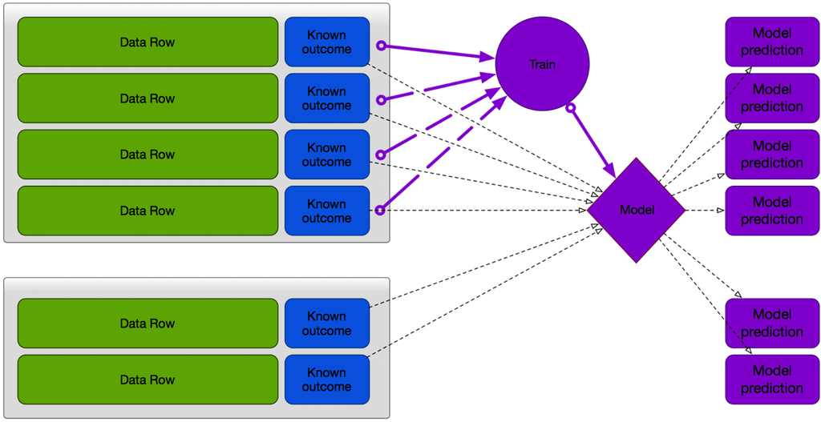

Source: Google Search

# 怎麼切分你的訓練與測試 - Hands on

- 洗牌我們可以善用`sample()`函數，查詢一下`sample()`函數吧！

```r
titanic <- read.csv("/Users/tkuo/ntu_train/NTUTrainRL3/data/train.csv", header = TRUE)
titanic <- titanic %>% na.omit

# 洗牌
n <- nrow(titanic)
set.seed(123)
shuffledTitanic <- titanic[sample(n), ]

# 看看洗牌前與洗牌後的titanic
head(titanic)
```

```
##   PassengerId Survived Pclass
## 1           1        0      3
## 2           2        1      1
## 3           3        1      3
## 4           4        1      1
## 5           5        0      3
## 7           7        0      1
##                                                  Name    Sex Age SibSp
## 1                             Braund, Mr. Owen Harris   male  22     1
## 2 Cumings, Mrs. John Bradley (Florence Briggs Thayer) female  38     1
## 3                              Heikkinen, Miss. Laina female  26     0
## 4        Futrelle, Mrs. Jacques Heath (Lily May Peel) female  35     1
## 5                            Allen, Mr. William Henry   male  35     0
## 7                             McCarthy, Mr. Timothy J   male  54     0
##   Parch           Ticket    Fare Cabin Embarked
## 1     0        A/5 21171  7.2500              S
## 2     0         PC 17599 71.2833   C85        C
## 3     0 STON/O2. 3101282  7.9250              S
## 4     0           113803 53.1000  C123        S
## 5     0           373450  8.0500              S
## 7     0            17463 51.8625   E46        S
```

```r
head(shuffledTitanic)
```

```
##     PassengerId Survived Pclass
## 255         255        0      3
## 708         708        1      1
## 364         364        0      3
## 788         788        0      3
## 836         836        1      1
## 42           42        0      2
##                                                         Name    Sex Age
## 255                 Rosblom, Mrs. Viktor (Helena Wilhelmina) female  41
## 708                        Calderhead, Mr. Edward Pennington   male  42
## 364                                          Asim, Mr. Adola   male  35
## 788                                Rice, Master. George Hugh   male   8
## 836                              Compton, Miss. Sara Rebecca female  39
## 42  Turpin, Mrs. William John Robert (Dorothy Ann Wonnacott) female  27
##     SibSp Parch             Ticket    Fare Cabin Embarked
## 255     0     2             370129 20.2125              S
## 708     0     0           PC 17476 26.2875   E24        S
## 364     0     0 SOTON/O.Q. 3101310  7.0500              S
## 788     4     1             382652 29.1250              Q
## 836     1     1           PC 17756 83.1583   E49        C
## 42      1     0              11668 21.0000              S
```

```r
# 依照70%:30%的比例切分training與test
trainingIndices <- 1:round(0.7 * n)
training <- shuffledTitanic[trainingIndices, ]
testIndices <- (round(0.7 * n) + 1):n
test <- shuffledTitanic[testIndices, ]

# 印出training與test的結構
str(training)
```

```
## 'data.frame':    500 obs. of  12 variables:
##  $ PassengerId: int  255 708 364 788 836 42 468 792 489 400 ...
##  $ Survived   : int  0 1 0 0 1 0 0 0 0 1 ...
##  $ Pclass     : int  3 1 3 3 1 2 1 2 3 2 ...
##  $ Name       : Factor w/ 891 levels "Abbing, Mr. Anthony",..: 707 127 41 688 176 832 771 283 779 826 ...
##  $ Sex        : Factor w/ 2 levels "female","male": 1 2 2 2 1 1 2 2 2 1 ...
##  $ Age        : num  41 42 35 8 39 27 56 16 30 28 ...
##  $ SibSp      : int  0 0 0 4 1 1 0 0 0 0 ...
##  $ Parch      : int  2 0 0 1 1 0 0 0 0 0 ...
##  $ Ticket     : Factor w/ 681 levels "110152","110413",..: 459 581 642 481 610 54 45 140 518 141 ...
##  $ Fare       : num  20.21 26.29 7.05 29.12 83.16 ...
##  $ Cabin      : Factor w/ 148 levels "","A10","A14",..: 1 122 1 1 132 1 1 1 1 1 ...
##  $ Embarked   : Factor w/ 4 levels "","C","Q","S": 4 4 4 3 2 4 4 4 4 4 ...
##  - attr(*, "na.action")=Class 'omit'  Named int [1:177] 6 18 20 27 29 30 32 33 37 43 ...
##   .. ..- attr(*, "names")= chr [1:177] "6" "18" "20" "27" ...
```

```r
str(test)
```

```
## 'data.frame':    214 obs. of  12 variables:
##  $ PassengerId: int  98 653 406 852 878 451 876 832 243 536 ...
##  $ Survived   : int  1 0 0 0 0 0 1 1 0 1 ...
##  $ Pclass     : int  1 3 2 3 3 2 3 2 2 2 ...
##  $ Name       : Factor w/ 891 levels "Abbing, Mr. Anthony",..: 313 426 279 800 662 861 576 691 170 346 ...
##  $ Sex        : Factor w/ 2 levels "female","male": 2 2 2 2 2 2 1 2 2 1 ...
##  $ Age        : num  23 21 34 74 19 36 15 0.83 29 7 ...
##  $ SibSp      : int  0 0 1 0 0 1 0 1 0 0 ...
##  $ Parch      : int  1 0 0 0 0 2 0 1 0 2 ...
##  $ Ticket     : Factor w/ 681 levels "110152","110413",..: 613 513 231 318 359 562 196 238 675 572 ...
##  $ Fare       : num  63.36 8.43 21 7.78 7.9 ...
##  $ Cabin      : Factor w/ 148 levels "","A10","A14",..: 93 1 1 1 1 1 1 1 1 1 ...
##  $ Embarked   : Factor w/ 4 levels "","C","Q","S": 2 4 4 4 4 4 2 4 4 4 ...
##  - attr(*, "na.action")=Class 'omit'  Named int [1:177] 6 18 20 27 29 30 32 33 37 43 ...
##   .. ..- attr(*, "names")= chr [1:177] "6" "18" "20" "27" ...
```

# 怎麼切分你的訓練與測試 - Do It Yourself

- 我希望training約有536個觀測值, test約有178個觀測值

```r
# 536 / 714 = 0.75
# 依照75%:25%的比例切分training與test
trainingIndices <- 1:round(0.75 * n)
training <- shuffledTitanic[trainingIndices, ]
testIndices <- (round(0.75 * n) + 1):n
test <- shuffledTitanic[testIndices, ]
```

# 更細膩精準地切分你的訓練與測試

- 在前面的例子我們只使用一次`sample()`函數
- 更細膩的方法稱為**交叉驗證(cross validation)**
- 最後以平均的指標(可能是accuracy或TPR…etc.)作為結果

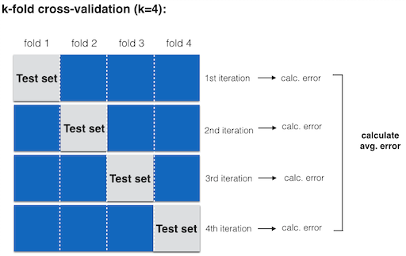

Source: Google Search

# 更細膩精準地切分你的訓練與測試 - Hands on

- 用`Pclass`, `Sex`, 與`Age`作為預測變數就好
- k-fold cross validation, k = 4

```r
titanic <- read.csv("/Users/tkuo/ntu_train/NTUTrainRL3/data/train.csv", header = TRUE)
titanic <- titanic[, c("Survived", "Pclass", "Sex", "Age")]
titanic <- titanic %>% na.omit
titanic$Survived <- as.factor(titanic$Survived)
titanic$Pclass <- as.factor(titanic$Pclass)

# 洗牌
n <- nrow(titanic)
set.seed(123)
shuffledTitanic <- titanic[sample(n), ]

# accuracies向量
accuracies <- rep(NA, times = 4)

for (i in 1:4) {
  # test的列數
  indices <- (((i-1) * round((1/4)*nrow(shuffledTitanic))) + 1):((i*round((1/4) * nrow(shuffledTitanic))))
  training <- shuffledTitanic[-indices,]
  test <- shuffledTitanic[indices,]
  # 設定亂數種子
  set.seed(123)
  # 建立決策樹模型
  tree <- rpart(Survived ~ ., training, method = "class")

  # 預測
  prediction <- predict(tree, test, type="class")

  # 建立混淆矩陣
  confusionMatrix <- table(test$Survived, prediction)

  # 把每次的accuracy放回accuracies向量
  accuracies[i] <- sum(diag(confusionMatrix))/(sum(confusionMatrix))
}
# 平均這4個accuracy
mean(accuracies)
```

```
## [1] 0.7780899
```

# 更細膩精準地切分你的訓練與測試 - Do It Yourself

- k-fold cross validation, k = 8
- 將平均的 accuracies 印出

```r
# 洗牌
n <- nrow(titanic)
set.seed(123)
shuffledTitanic <- titanic[sample(n), ]

# accuracies向量
accuracies <- rep(NA, times = 8)
kFold <- length(accuracies)

for (i in 1:kFold) {
  # test的列數
  indices <- (((i-1) * round((1/kFold)*nrow(shuffledTitanic))) + 1):((i*round((1/kFold) * nrow(shuffledTitanic))))
  training <- shuffledTitanic[-indices,]
  test <- shuffledTitanic[indices,]
  # 設定亂數種子
  set.seed(123)
  # 建立決策樹模型
  tree <- rpart(Survived ~ ., training, method = "class")

  # 預測
  prediction <- predict(tree, test, type="class")

  # 建立混淆矩陣
  confusionMatrix <- table(test$Survived, prediction)

  # 把每次的accuracy放回accuracies向量
  accuracies[i] <- sum(diag(confusionMatrix))/(sum(confusionMatrix))
}
# 平均這8個accuracy
mean(accuracies)
```

```
## [1] 0.7766854
```

# Underfitting vs. Overfitting?

- 你是否常常聽到人家說underfitting或overfitting?

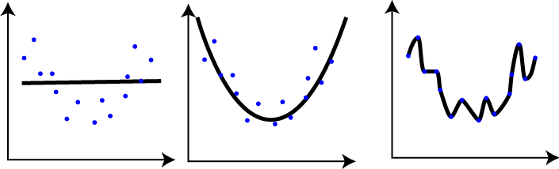

Source: Google Search

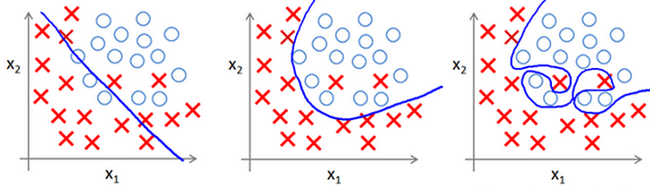

Source: Google Search

- 在**適用性**與**精確性**之間取得良好的平衡

# Underfitting vs. Overfitting? - Hands on

- 我們的分類器overfitting(對訓練資料集的分類完全正確, accuracy = 100%)
- 但是對測試資料集的分類accuracy僅有62.5%

```r
# 倒帳資料集
debtIncomeRatio <- c(1, 2.112, 4.123, 1.863, 2.973, 1.687, 5.891, 3.167, 1.23, 2.441, 3.555, 3.25, 1.333)
default <- c(0, 0, 1, 0, 1, 0, 1, 0, 0, 1, 0, 0, 1)
defaultDataTrain <- data.frame(debtIncomeRatio, default)
defaultDataTrain$default <- factor(defaultDataTrain$default)

# 分類器
default_classifier <- function(x){
  prediction <- rep(NA, length(x))
  prediction[x > 4] <- 1
  prediction[x >= 3 & x <= 4] <- 0
  prediction[x >= 2.2 & x < 3] <- 1
  prediction[x >= 1.4 & x < 2.2] <- 0
  prediction[x > 1.25 & x < 1.4] <- 1
  prediction[x <= 1.25] <- 0
  return(prediction)
}

# training資料集的accuracy
defaultPredictionOverTrain <- default_classifier(defaultDataTrain$debtIncomeRatio)
confusionMatrixOverTrain <- table(defaultDataTrain$default, defaultPredictionOverTrain)
accuracyOverTrain <- sum(diag(confusionMatrixOverTrain)) / sum(confusionMatrixOverTrain)
accuracyOverTrain
```

```
## [1] 1
```

```r
# test資料集
debtIncomeRatio <- c(1.5,   4.941,  3.429,  3.493,  3.38,   3.689,  1,  6.761,  2.195,  2.857,  1.883,  1.744,  2.325,  1.25,   1.8,    2.5,    4.617,  2.206,  8.323,  3.764,  1.932,  3.153,  1.983,  3.812,  4.295,  4.5,    1.3,    1,  5.009,  5.888,  1,  3.456,  3.379,  1.755,  2.333,  2.188,  1.406,  1.857,  3.707,  3.766,  2.93,   2.076,  1.9,    1.684,  2.769,  4.571,  3.029,  3.628)
default <- c(0,     1,  1,  1,  0,  1,  0,  1,  1,  0,  0,  0,  0,  0,  1,  0,  1,  0,  1,  0,  0,  0,  0,  1,  0,  1,  0,  0,  1,  0,  0,  1,  0,  0,  0,  0,  0,  0,  1,  0,  1,  0,  0,  1,  1,  0,  0,  0)
defaultDataTest <- data.frame(debtIncomeRatio, default)
defaultDataTest$default <- as.factor(defaultDataTest$default)

# test資料集的accuracy
defaultPredictionOverTest <- default_classifier(defaultDataTest$debtIncomeRatio)
confusionMatrixOverTest <- table(defaultDataTest$default, defaultPredictionOverTest)
accuracyOverTest <- sum(diag(confusionMatrixOverTest)) / sum(confusionMatrixOverTest)
accuracyOverTest
```

```
## [1] 0.625
```

# Underfitting vs. Overfitting? - Do It Yourself

- 用新的分類器對**訓練**資料分類並計算accuracy
- 用新的分類器對**測試**資料分類並計算accuracy
- 跟前面的例子比較一下

```r
# 新的分類器
default_classifier <- function(x){
  prediction <- rep(NA, length(x))
  prediction[x > 4] <- 1
  prediction[x <= 4] <- 0
  return(prediction)
}

# training資料集的accuracy
defaultPredictionTrain <- default_classifier(defaultDataTrain$debtIncomeRatio)
confusionMatrixTrain <- table(defaultDataTrain$default, defaultPredictionTrain)
accuracyTrain <- sum(diag(confusionMatrixTrain)) / sum(confusionMatrixTrain)
accuracyTrain
```

```
## [1] 0.7692308
```

```r
# test資料集的accuracy
defaultPredictionTest <- default_classifier(defaultDataTest$debtIncomeRatio)
confusionMatrixTest <- table(defaultDataTest$default, defaultPredictionTest)
accuracyTest <- sum(diag(confusionMatrixTest)) / sum(confusionMatrixTest)
accuracyTest
```

```
## [1] 0.7083333
```